# All About Data Wrangling in R!

Hannah Peterson

04/01/22

```r
# Load the R Packages we need
library(tidyverse)
library(fueleconomy)
```

For this tutorial, we’ll be using the `vehicles` dataset from the `fueleconomy` package. As described by the creator, this dataset includes “fuel economy data from the EPA, 1985-2015. This dataset contains selected variables, and removes vehicles with incomplete data (e.g. no drive train data).” Here’s a snippet of the data:

```
## # A tibble: 33,442 × 12
##       id make  model        year class trans drive   cyl displ fuel    hwy   cty
##    <dbl> <chr> <chr>       <dbl> <chr> <chr> <chr> <dbl> <dbl> <chr> <dbl> <dbl>
##  1 13309 Acura 2.2CL/3.0CL  1997 Subc… Auto… Fron…     4   2.2 Regu…    26    20
##  2 13310 Acura 2.2CL/3.0CL  1997 Subc… Manu… Fron…     4   2.2 Regu…    28    22
##  3 13311 Acura 2.2CL/3.0CL  1997 Subc… Auto… Fron…     6   3   Regu…    26    18
##  4 14038 Acura 2.3CL/3.0CL  1998 Subc… Auto… Fron…     4   2.3 Regu…    27    19
##  5 14039 Acura 2.3CL/3.0CL  1998 Subc… Manu… Fron…     4   2.3 Regu…    29    21
##  6 14040 Acura 2.3CL/3.0CL  1998 Subc… Auto… Fron…     6   3   Regu…    26    17
##  7 14834 Acura 2.3CL/3.0CL  1999 Subc… Auto… Fron…     4   2.3 Regu…    27    20
##  8 14835 Acura 2.3CL/3.0CL  1999 Subc… Manu… Fron…     4   2.3 Regu…    29    21
##  9 14836 Acura 2.3CL/3.0CL  1999 Subc… Auto… Fron…     6   3   Regu…    26    17
## 10 11789 Acura 2.5TL        1995 Comp… Auto… Fron…     5   2.5 Prem…    23    18
## # … with 33,432 more rows
```

# What’s Data Wrangling?

We’ll be using `dplyr` to wrangle data in R. This, along with ggplot2, automatically loads with `library(tidyverse)`. `dplyr` provides a grammar for data transformation with five main functions:

- `select()`: return a subset of columns (aka variables)
- `filter()`: return a subset of rows
- `mutate()`: add or modify existing columns; defines and inserts *new variables* into a data frame as columns
- `arrange():` sort rows by specific columns
  - By default, this arranges in *ascending order* - to sort in *descending order*, use `desc()` around the variables within `arrange()`
- `summarize()`: aggregate data across rows (e.g. grouped means); collapses the data into rows based on summary statistics (mean(), sd(), median(), max(), n(), etc.)

These functions take a *data frame* as its first argument and use the pipe operator `%>%` to connect arguments.

Some other useful `dplyr` functions include:

- `rename()`: rename existing columns (variables)
- `group_by()`: used with a function that performs a calculation (such as `summarize()`), this groups by a specified variable
- `count()`: counts the number of occurrences
- `slice()`: returns specified indices (rows)
- `slice_max()`: returns a specified number of rows with the highest values of the specified variable

**NOTE:** If a dataset has missing values, add `na.rm = TRUE` to remove them from any calculations. Luckily, our dataset doesn’t have any.

Let’s see these in action! We’ll be using the `vehicles` dataset as mentioned above.

## Example 1

Let’s find the average city miles per gallon (`cty`) for cars from 1999:

- We start with our dataset, pipe it to a `filter()` with our specification of `year == 1999`, and then pipe to a `summarize()` where we display the mean of all of our 1999 cars’ `cty` mpg.

```r
vehicles %>%
  filter(year == 1999) %>%
  summarize(mean(cty))
```

```
## # A tibble: 1 × 1
##   `mean(cty)`
##         <dbl>
## 1        17.1
```

This tells us that the average city miles per gallon for cars made in 1999 is 17.1.

## Example 2

- NOTE: Since this dataset includes electric cars, we’ll use `fuel != "Electricity"` within our filter step to only deal with cars that aren’t electric.
- We start with our dataset, pipe it to a `filter()` with our specification of `year == 2015 & fuel != "Electricity"`, and then pipe to `arrange(desc(cty))` which arranges the data in descending order of their `cty` value. Then we pipe to `select(make, model, cty, trans)` which selects which variables we’d like to display, and finally we use `slice(1:5)` which “slices” the table to only show us the first 5 rows.

```r
vehicles %>%
  filter(year == 2015 & fuel != "Electricity") %>%
  arrange(desc(cty)) %>%
  select(make, model, cty, trans) %>%
  slice(1:5)
```

```
## # A tibble: 5 × 4
##   make      model     cty trans
##   <chr>     <chr>   <dbl> <chr>
## 1 Honda     Fit        33 Automatic (variable gear ratios)
## 2 Honda     Fit        32 Auto(AV-S7)
## 3 Lexus     RX 450h    32 Auto(AV-S6)
## 4 Chevrolet Spark      31 Manual 5-spd
## 5 Nissan    Versa      31 Automatic (variable gear ratios)
```

This tells us that in 2015, the best city mpg in a non-electric car was the Honda Fit with the automatic variable gears ratios transmission, followed by the Honda Fit with the automatic AV-S7 transmission, and then the Lexus RX 450h, Chevrolet Spark, and Nissan Versa, respectively.

## Example 3

Now let’s use a combination of `dplyr` and `ggplot` to wrangle data *and* visualize it.

- We first pipe our dataset to `count(class)` which “counts” up how many vehicles there are within each class. Then, we pipe to `slice_max(order_by = n, n = 10)` to get the 10 most popular classes. Next, we pipe this to ggplot! We specify `fct_reorder(class,-n)` as x, which simply reorders the bars so that they’re in descending order of n, and we use `y = n` because n represnts our counts for each class. Because we used `count()` in our pipeline, we have to use `geom_col()` instead of `geom_bar()` so that we can specify both our x and y. Finally, we add labels with `labs()` and flip the coordinates with `coord_flip()`.

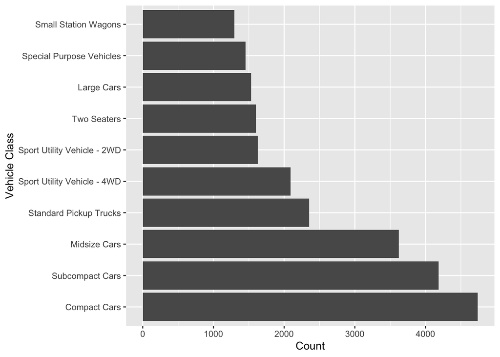

```r
vehicles %>%
  count(class) %>%
  slice_max(order_by = n, n = 10) %>%
  ggplot(aes(x = fct_reorder(class,-n), y = n)) +
  geom_col() +
  labs(x = "Vehicle Class", y = "Count") +
  coord_flip()
```

This shows us the top 10 most popular classes for each unique vehicle model produced throughout the years.

## Example 4

Now let’s look at during which years Toyota Corollas were produced, let’s specify them by their transmission type, and let’s also look at their city mpg rating.

- We first pipe our dataset to `filter(model == "Corolla")` which selects only the vehicles whose model is “Corolla.” Then, we pipe to `ggplot()` and specify x as `year`, y as `cty`, and color as `trans`. Next, we’ll add `geom_point()` for our scatterplot and `facet_wrap(~ trans)` to seperate our graphs by transmission. Finally, `theme(legend.position = "none")` allows us to get rid of a self-explanatory color legend, and we add our labels with `labs()`.

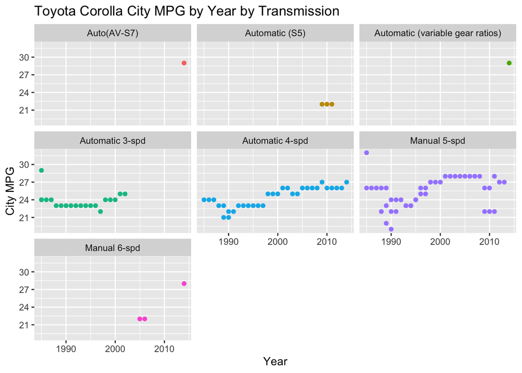

```r
vehicles %>%
  filter(model == "Corolla") %>%
  ggplot(aes(x = year, y = cty, color = trans)) +
  geom_point() +
  facet_wrap(~ trans) +
  theme(legend.position = "none") +
  labs(x = "Year", y = "City MPG", title = "Toyota Corolla City MPG by Year by Transmission")
```

This visualization tells us a few things!

- We can see that Toyota’s two main transmissions for the corolla are automatic 4 speed and manual 5 speed, since those two graphs clearly have the most data points.
- We can see that Corolla’s with AV-S7 and variable gear ratios transmissions were only produced for one year; S5 and manual 6 speed transmissions were only produced for three years; and the automatic 3 speed was produced regularly up until around 2002.
- We can see that there’s generally a trend of city mpg rising over the years.